# Statistical Analysis

## Producing complete tidy-data and handling the outlier

To analyze the effect hypothesized, we firstly combine all data together.

```r
# put all types of dataframe together to form a complete one:
aggregate_data <- inner_join(personality, visit_scale_score, by = "Key") %>%
  left_join(eye_data, by = c("Key", "Scenario", "Level of Vitality")) %>%
  select(RecordedDate, Key, `Level of Vitality`, Scenario, everything()) %>%
  mutate(`Level of Trust` = if_else(`Interpersonal Trust` >= median(.$`Interpersonal Trust`), "High", "Low") %>% factor()) %>% ungroup()
```

We try to kick the outliers. Eye-tracking metrics seldom follow normal distribution, therefore the criteria of outliers is based on distribution of data rather than standardized *Z*-score.

```r
# outlier removing function
remove_outliers <- function(x, na.rm = TRUE, ...) {
  qnt <- quantile(x, probs=c(.25, .75), na.rm = na.rm, ...)
  H <- 1.5 * IQR(x, na.rm = na.rm)
  y <- x
  y[x < (qnt[1] - H)] <- NA
  y[x > (qnt[2] + H)] <- NA
  y
}

# apply the function to DV
aggregate_data_screen <- aggregate_data %>% mutate_at(vars(Satisfaction:Vitality_attention_standardized), remove_outliers)
```

## Analysis: adjunctive stat analysis

By drawing the graph, we could see the distribution of the data, maybe giving us insights for later analysis.

```r
# exploratory data insight: ggplot to find hidden rules.
# for different scenario and PRS subscale: facet 4 by 4.
ggplot(data = aggregate_data_screen %>% gather(Escape:Compatibility, key = 'variable', value = 'Score'),
       aes(x = `Interpersonal Trust`, y = Score)) +
  geom_point(aes(color = `Level of Vitality`),  shape = 16, alpha = 0.4) +
  geom_smooth(aes(color = `Level of Vitality`), method = "lm") +
  facet_grid(variable ~ Scenario, scales = "free_y") +
  theme(legend.position = "bottom")

# for different vitality level and PRS subscale: facet 2 by 4
ggplot(data = aggregate_data %>% gather(Escape:Compatibility, key = 'variable', value = 'Score'),
       aes(x = `Interpersonal Trust`, y = Score)) +
  geom_point(aes(color = `Scenario`),  alpha = 0.4) +
  geom_smooth(aes(color = `Scenario`), method = "lm") +
  facet_grid(variable ~ `Level of Vitality`, scales = "free_y")

# fixation is significant
ggplot(aggregate_data_screen %>%
         gather(Average_duration_of_whole_fixations, Average_amplitude_of_saccades, key = 'variable', value = 'Score') %>%
         mutate(variable = fct_relabel(variable, ~ str_replace_all(., '_', ' ') %>%
                                         str_remove(., ' whole') %>% paste(c("[°]", "[ms]")))),
       aes(x = `Interpersonal Trust`, y = Score)) +
  geom_point(aes(color = `Level of Vitality`), shape = 16, alpha = 0.4) +
  geom_smooth(aes(color = `Level of Vitality`), method = "lm") +
  scale_y_continuous(name = "Value") +
  facet_grid(variable ~ Scenario, scales = "free_y") +
  theme(legend.position = "bottom")
```

[output not shown]

Firstly, we want to ensure whether all four dimension of PRS scale can properly reflect the restoration construct, which predict satisfaction based on ART.

```r
aggregate_data %>% select(Satisfaction:Compatibility) %>% corr.test(use = "pairwise")
```

```
Call:corr.test(x = ., use = "pairwise")
Correlation matrix
              Satisfaction Escape Fascination Coherence Compatibility
Satisfaction          1.00   0.81        0.79     -0.43          0.80
Escape                0.81   1.00        0.72     -0.42          0.81
Fascination           0.79   0.72        1.00     -0.22          0.76
Coherence            -0.43  -0.42       -0.22      1.00         -0.41
Compatibility         0.80   0.81        0.76     -0.41          1.00
Sample Size
[1] 287
Probability values (Entries above the diagonal are adjusted for multiple tests.)
              Satisfaction Escape Fascination Coherence Compatibility
Satisfaction             0      0           0         0             0
Escape                   0      0           0         0             0
Fascination              0      0           0         0             0
Coherence                0      0           0         0             0
Compatibility            0      0           0         0             0

 To see confidence intervals of the correlations, print with the short=FALSE option
```

Next, we want to explore the relationship between restoration and visual attention level. According to attention restorative theory, one will pay more involuntary attention to the environment if it is perceived as restorative. Yet we need a single metric to represent restoration level… maybe PCA is a good idea?

```
Parallel analysis suggests that the number of factors =  NA  and the number of components =  1
```

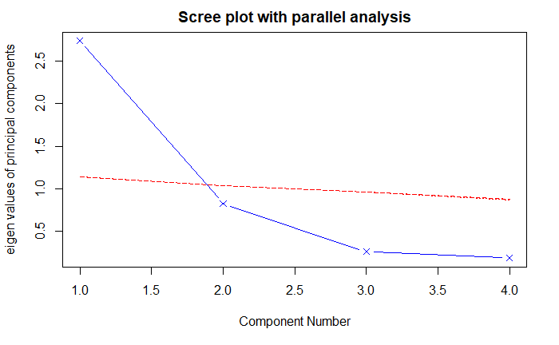

```r
# aggregate_data, yyds.
for_pca <- aggregate_data %>% select(Escape:Compatibility)
# Scree plot: how many components should be extracted?
fa.parallel(for_pca, fa="pc", n.iter=100, show.legend=FALSE, main="Scree plot with parallel analysis")
```

```r
# principal analysis and output the principal score.
pca <- principal(for_pca, nfactors = 1, scores = TRUE)
aggregate_data_plus <- aggregate_data %>% mutate(Restoration = pca$scores)

# Compute the correlation to verify the ART.
aggregate_data_plus %>% select(Total_duration_of_whole_fixations:Saccade_frequency, Average_pupil_size) %>%
  map(~ cor.test(., aggregate_data_plus$Restoration))
```

```
$Total_duration_of_whole_fixations

    Pearson's product-moment correlation

data:  . and aggregate_data_plus$Restoration
t = -0.23443, df = 285, p-value = 0.8148
alternative hypothesis: true correlation is not equal to 0
95 percent confidence interval:
 -0.1294577  0.1020601
sample estimates:
        cor
-0.01388489


$Average_duration_of_whole_fixations

    Pearson's product-moment correlation

data:  . and aggregate_data_plus$Restoration
t = -3.3702, df = 285, p-value = 0.0008549
alternative hypothesis: true correlation is not equal to 0
95 percent confidence interval:
 -0.3046440 -0.0818424
sample estimates:
       cor
-0.1957682


$Number_of_whole_fixations

    Pearson's product-moment correlation

data:  . and aggregate_data_plus$Restoration
t = 3.2494, df = 285, p-value = 0.001295
alternative hypothesis: true correlation is not equal to 0
95 percent confidence interval:
 0.07486404 0.29826063
sample estimates:
      cor
0.1890067
```

[output cut: 111 more lines]

```
0.1564466


$Average_pupil_size

    Pearson's product-moment correlation

data:  . and aggregate_data_plus$Restoration
t = -2.6674, df = 285, p-value = 0.008082
alternative hypothesis: true correlation is not equal to 0
95 percent confidence interval:
 -0.26702192 -0.04102637
sample estimates:
       cor
-0.1560659
```

```r
# another coding style...
corr.test(aggregate_data_plus %>% select(Restoration), aggregate_data_plus %>% select(Total_duration_of_whole_fixations:Saccade_frequency, Average_pupil_size), use = "pairwise.complete.obs")
```

```
Call:corr.test(x = aggregate_data_plus %>% select(Restoration), y = aggregate_data_plus %>%
    select(Total_duration_of_whole_fixations:Saccade_frequency,
        Average_pupil_size), use = "pairwise.complete.obs")
Correlation matrix
            Total_duration_of_whole_fixations Average_duration_of_whole_fixations Number_of_whole_fixations
Restoration                             -0.01                                -0.2                      0.19
            Number_of_saccades Average_peak_velocity_of_saccades
Restoration               0.16                             -0.05
            Standard_deviation_of_peak_velocity_of_saccades Average_amplitude_of_saccades
Restoration                                               0                         -0.01
            Total_amplitude_of_saccades Fixation_frequency Duration_proportion_of_fixations
Restoration                        0.13               0.19                            -0.01
            Saccade_frequency Average_pupil_size
Restoration              0.16              -0.16
Sample Size
    Total_duration_of_whole_fixations Average_duration_of_whole_fixations Number_of_whole_fixations
PC1                               287                                 287                       287
    Number_of_saccades Average_peak_velocity_of_saccades Standard_deviation_of_peak_velocity_of_saccades
PC1                287                               287                                             286
    Average_amplitude_of_saccades Total_amplitude_of_saccades Fixation_frequency
PC1                           287                         287                287
    Duration_proportion_of_fixations Saccade_frequency Average_pupil_size
PC1                              287               287                287
Probability values  adjusted for multiple tests.
            Total_duration_of_whole_fixations Average_duration_of_whole_fixations Number_of_whole_fixations
Restoration                                 1                                0.01                      0.01
            Number_of_saccades Average_peak_velocity_of_saccades
Restoration               0.07                                 1
            Standard_deviation_of_peak_velocity_of_saccades Average_amplitude_of_saccades
Restoration                                               1                             1
            Total_amplitude_of_saccades Fixation_frequency Duration_proportion_of_fixations
Restoration                        0.15               0.01                                1
            Saccade_frequency Average_pupil_size
Restoration              0.07               0.07

 To see confidence intervals of the correlations, print with the short=FALSE option
```

Analysis the gender difference:

```r
testInteractions(fit_repeated_v2, idata = in_repeated_v2, fixed = "Vitality", across = "Gender")
```

```
Multivariate Test: Pillai test statistic
P-value adjustment method: holm
        Value Df test stat approx F num Df den Df   Pr(>F)
High  0.16846  1  0.014459    0.983      1     67 0.325039
 Low -0.50887  1  0.127718    9.810      1     67 0.005147 **
---
Signif. codes:  0 ‘***’ 0.001 ‘**’ 0.01 ‘*’ 0.05 ‘.’ 0.1 ‘ ’ 1
```

## Analysis: main hypothesis

Our plan is choosing all dependent variables to form a complete dataset. Then write a function for analyzing simply one column of dependent variable. All analyzing process would be iterated by **purrr::map()** function.

```r
# all dependent variables: dv_columns.
dv_columns <- aggregate_data_screen %>% select(Escape:Compatibility, Average_duration_of_whole_fixations, Average_peak_velocity_of_saccades, Average_amplitude_of_saccades, Average_pupil_size, Total_amplitude_of_saccades:Saccade_frequency, Vitality_attention, Vitality_attention_standardized)
dv_names <- names(dv_columns)
```

Therefore, a more advanced model is adopted. Hierarchical linear model (HLM) is suitable for analysis with great variance between groups. Here, sceanrio variable is regarded as grouping variable to seperate more variance.

```r
hlm_framework_v2 <- function(test_column){

  # HLM: hierarchical linear model:
  #   one dependent variable is picked up and added to the last column,
  #   to form a complete dataset named "restructured".

  restructured <- aggregate_data_screen %>% select(Key:`Interpersonal Trust`) %>% add_column(var = test_column) %>% rename(Vitality = `Level of Vitality`, Trust = `Interpersonal Trust`)

  # building the model.
  model2 <- lmer(var ~ Vitality * Trust + (1 | Scenario), data = restructured, na.action = na.exclude)
  # model3 <- lmer(var ~ Vitality * Trust + (1 | Scenario) + (1 | Key), data = restructured, na.action = na.exclude)
  # model_inter <- lmer(var ~ Vitality * Trust + (Vitality | Scenario), data = restructured, na.action = na.exclude)

  # return zone
  return(model2)
}
hlm_results <- dv_columns %>% map(hlm_framework_v2)
```

```
boundary (singular) fit: see ?isSingular
boundary (singular) fit: see ?isSingular
boundary (singular) fit: see ?isSingular
```

```r
hlm_results %>% map(summary)
```

```
$Escape
Linear mixed model fit by REML. t-tests use Satterthwaite's method ['lmerModLmerTest']
Formula: var ~ Vitality * Trust + (1 | Scenario)
   Data: restructured

REML criterion at convergence: 951.5

Scaled residuals:
    Min      1Q  Median      3Q     Max
-2.8203 -0.6836 -0.0665  0.6521  3.2401

Random effects:
 Groups   Name        Variance Std.Dev.
 Scenario (Intercept) 0.8338   0.9131
 Residual             1.5337   1.2384
Number of obs: 287, groups:  Scenario, 4

Fixed effects:
                  Estimate Std. Error       df t value Pr(>|t|)
(Intercept)         3.1619     0.8191  28.1598   3.860 0.000606 ***
VitalityLow         1.2778     0.9057 279.9995   1.411 0.159400
Trust               0.1824     0.2674 279.9995   0.682 0.495879
VitalityLow:Trust  -0.3626     0.3619 279.9995  -1.002 0.317247
---
Signif. codes:  0 ‘***’ 0.001 ‘**’ 0.01 ‘*’ 0.05 ‘.’ 0.1 ‘ ’ 1

Correlation of Fixed Effects:
            (Intr) VtltyL Trust
VitalityLow -0.623
Trust       -0.821  0.742
VtltyLw:Trs  0.606 -0.987 -0.739

$Fascination
Linear mixed model fit by REML. t-tests use Satterthwaite's method ['lmerModLmerTest']
Formula: var ~ Vitality * Trust + (1 | Scenario)
   Data: restructured

REML criterion at convergence: 871.7

Scaled residuals:
```

[output cut: 401 more lines]

```

Fixed effects:
                  Estimate Std. Error       df t value Pr(>|t|)
(Intercept)         3.5185     0.9141  55.0911   3.849 0.000311 ***
VitalityLow        -0.5323     1.1237 253.0383  -0.474 0.636115
Trust              -0.1506     0.3199 253.0232  -0.471 0.638199
VitalityLow:Trust   0.4460     0.4491 253.0233   0.993 0.321677
---
Signif. codes:  0 ‘***’ 0.001 ‘**’ 0.01 ‘*’ 0.05 ‘.’ 0.1 ‘ ’ 1

Correlation of Fixed Effects:
            (Intr) VtltyL Trust
VitalityLow -0.644
Trust       -0.880  0.716
VtltyLw:Trs  0.627 -0.986 -0.712
```

In fact, the results of HLM analysis is not good enough. From the exploratory plotting graph we can clearly see the influential pattern of data varies a lot among different scenarios. Thus we analyse the moderation effect separately within each scenario.

```r
scene_grouped <- aggregate_data_screen %>% split(.$Scenario)

moderation_on_one_scene <- function(one_scene){
  # center the moderate variable: ITS
  one_scene <- one_scene %>% mutate(`Interpersonal Trust Centered` = scale(`Interpersonal Trust`, center = TRUE, scale = TRUE))

  moderation_within_scene <- function(dv_name){
    #dv_name is a character string
    chosen <- one_scene %>% select(Vitality = `Level of Vitality`, Trust = `Interpersonal Trust Centered`, var = all_of(dv_name))

    fit0 <- lm(var ~ Vitality + Trust, data = chosen, na.action = na.exclude)
    fit1 <- lm(var ~ Vitality * Trust, data = chosen, na.action = na.exclude)
    comparison <- anova(fit0, fit1)
    return(list(fit0 = fit0, fit1 = fit1, compare = comparison))
  }

  fit_batch <- dv_names %>% map(moderation_within_scene)
  fit_batch <- fit_batch %>% set_names(dv_names)
  return(fit_batch)
}

fit_folded_batch <- scene_grouped %>% map(moderation_on_one_scene)
fit_folded_batch$`Business District` %>% map(~ map(., summary))
```

```
$Escape
$Escape$fit0

Call:
lm(formula = var ~ Vitality + Trust, data = chosen, na.action = na.exclude)

Residuals:
    Min      1Q  Median      3Q     Max
-2.7259 -0.6889 -0.1907  0.7482  2.9263

Coefficients:
            Estimate Std. Error t value Pr(>|t|)
(Intercept)  3.41535    0.20755  16.456   <2e-16 ***
VitalityLow  0.65264    0.29457   2.216     0.03 *
Trust       -0.03578    0.14832  -0.241     0.81
---
Signif. codes:  0 ‘***’ 0.001 ‘**’ 0.01 ‘*’ 0.05 ‘.’ 0.1 ‘ ’ 1

Residual standard error: 1.241 on 69 degrees of freedom
Multiple R-squared:  0.06968,   Adjusted R-squared:  0.04271
F-statistic: 2.584 on 2 and 69 DF,  p-value: 0.08277


$Escape$fit1

Call:
lm(formula = var ~ Vitality * Trust, data = chosen, na.action = na.exclude)

Residuals:
    Min      1Q  Median      3Q     Max
-2.8274 -0.7205 -0.1404  0.7320  2.9236

Coefficients:
                  Estimate Std. Error t value Pr(>|t|)
(Intercept)        3.40572    0.20959  16.250   <2e-16 ***
VitalityLow        0.65426    0.29621   2.209   0.0306 *
Trust              0.04554    0.22133   0.206   0.8376
VitalityLow:Trust -0.14893    0.29954  -0.497   0.6206
---
Signif. codes:  0 ‘***’ 0.001 ‘**’ 0.01 ‘*’ 0.05 ‘.’ 0.1 ‘ ’ 1
```

[output cut: 761 more lines]

```

Residual standard error: 1.673 on 68 degrees of freedom
Multiple R-squared:  0.1442,    Adjusted R-squared:  0.1064
F-statistic: 3.819 on 3 and 68 DF,  p-value: 0.01368


$Vitality_attention_standardized$compare
     Res.Df           RSS              Df      Sum of Sq           F              Pr(>F)
 Min.   :68.00   Min.   :190.3   Min.   :1   Min.   :2.243   Min.   :0.8013   Min.   :0.3739
 1st Qu.:68.25   1st Qu.:190.9   1st Qu.:1   1st Qu.:2.243   1st Qu.:0.8013   1st Qu.:0.3739
 Median :68.50   Median :191.4   Median :1   Median :2.243   Median :0.8013   Median :0.3739
 Mean   :68.50   Mean   :191.4   Mean   :1   Mean   :2.243   Mean   :0.8013   Mean   :0.3739
 3rd Qu.:68.75   3rd Qu.:192.0   3rd Qu.:1   3rd Qu.:2.243   3rd Qu.:0.8013   3rd Qu.:0.3739
 Max.   :69.00   Max.   :192.6   Max.   :1   Max.   :2.243   Max.   :0.8013   Max.   :0.3739
                                 NA's   :1   NA's   :1       NA's   :1        NA's   :1
```

```r
fit_folded_batch$`Metro Station` %>% map(~ map(., summary))
```

```
$Escape
$Escape$fit0

Call:
lm(formula = var ~ Vitality + Trust, data = chosen, na.action = na.exclude)

Residuals:
    Min      1Q  Median      3Q     Max
-1.6051 -0.8534 -0.2408  0.6588  4.0098

Coefficients:
            Estimate Std. Error t value Pr(>|t|)
(Intercept)  2.27988    0.19320  11.800  < 2e-16 ***
VitalityLow  0.78182    0.27230   2.871  0.00545 **
Trust        0.05193    0.13624   0.381  0.70424
---
Signif. codes:  0 ‘***’ 0.001 ‘**’ 0.01 ‘*’ 0.05 ‘.’ 0.1 ‘ ’ 1

Residual standard error: 1.139 on 68 degrees of freedom
  (1 observation deleted due to missingness)
Multiple R-squared:  0.1082,    Adjusted R-squared:  0.08192
F-statistic: 4.123 on 2 and 68 DF,  p-value: 0.02041


$Escape$fit1

Call:
lm(formula = var ~ Vitality * Trust, data = chosen, na.action = na.exclude)

Residuals:
    Min      1Q  Median      3Q     Max
-1.5673 -0.7388 -0.2939  0.3795  3.7206

Coefficients:
                  Estimate Std. Error t value Pr(>|t|)
(Intercept)         2.2407     0.1874  11.958   <2e-16 ***
VitalityLow         0.7867     0.2631   2.990   0.0039 **
Trust               0.4009     0.1954   2.051   0.0442 *
VitalityLow:Trust  -0.6387     0.2644  -2.415   0.0185 *
---
```

[output cut: 769 more lines]

```
Residual standard error: 1.221 on 49 degrees of freedom
  (19 observations deleted due to missingness)
Multiple R-squared:  0.5927,    Adjusted R-squared:  0.5677
F-statistic: 23.76 on 3 and 49 DF,  p-value: 1.229e-09


$Vitality_attention_standardized$compare
     Res.Df           RSS              Df      Sum of Sq           F             Pr(>F)
 Min.   :49.00   Min.   :73.00   Min.   :1   Min.   :7.074   Min.   :4.748   Min.   :0.03417
 1st Qu.:49.25   1st Qu.:74.77   1st Qu.:1   1st Qu.:7.074   1st Qu.:4.748   1st Qu.:0.03417
 Median :49.50   Median :76.53   Median :1   Median :7.074   Median :4.748   Median :0.03417
 Mean   :49.50   Mean   :76.53   Mean   :1   Mean   :7.074   Mean   :4.748   Mean   :0.03417
 3rd Qu.:49.75   3rd Qu.:78.30   3rd Qu.:1   3rd Qu.:7.074   3rd Qu.:4.748   3rd Qu.:0.03417
 Max.   :50.00   Max.   :80.07   Max.   :1   Max.   :7.074   Max.   :4.748   Max.   :0.03417
                                 NA's   :1   NA's   :1       NA's   :1       NA's   :1
```

```r
fit_folded_batch$`Night Traffic` %>% map(~ map(., summary))
```

```
$Escape
$Escape$fit0

Call:
lm(formula = var ~ Vitality + Trust, data = chosen, na.action = na.exclude)

Residuals:
    Min      1Q  Median      3Q     Max
-2.5808 -1.3215  0.0794  0.9695  3.2214

Coefficients:
            Estimate Std. Error t value Pr(>|t|)
(Intercept)  3.92675    0.23859  16.458   <2e-16 ***
VitalityLow -0.05349    0.33862  -0.158    0.875
Trust       -0.17908    0.17050  -1.050    0.297
---
Signif. codes:  0 ‘***’ 0.001 ‘**’ 0.01 ‘*’ 0.05 ‘.’ 0.1 ‘ ’ 1

Residual standard error: 1.426 on 69 degrees of freedom
Multiple R-squared:  0.01575,   Adjusted R-squared:  -0.01278
F-statistic: 0.5522 on 2 and 69 DF,  p-value: 0.5782


$Escape$fit1

Call:
lm(formula = var ~ Vitality * Trust, data = chosen, na.action = na.exclude)

Residuals:
     Min       1Q   Median       3Q      Max
-2.50234 -1.29403 -0.06549  0.95805  2.90443

Coefficients:
                  Estimate Std. Error t value Pr(>|t|)
(Intercept)        3.94827    0.23971  16.471   <2e-16 ***
VitalityLow       -0.05712    0.33878  -0.169    0.867
Trust             -0.36101    0.25315  -1.426    0.158
VitalityLow:Trust  0.33320    0.34259   0.973    0.334
---
Signif. codes:  0 ‘***’ 0.001 ‘**’ 0.01 ‘*’ 0.05 ‘.’ 0.1 ‘ ’ 1
```

[output cut: 757 more lines]

```

Residual standard error: 0.5232 on 68 degrees of freedom
Multiple R-squared:  0.1052,    Adjusted R-squared:  0.06567
F-statistic: 2.664 on 3 and 68 DF,  p-value: 0.05481


$Vitality_attention_standardized$compare
     Res.Df           RSS              Df      Sum of Sq               F                Pr(>F)
 Min.   :68.00   Min.   :18.61   Min.   :1   Min.   :0.0007812   Min.   :0.002854   Min.   :0.9576
 1st Qu.:68.25   1st Qu.:18.61   1st Qu.:1   1st Qu.:0.0007812   1st Qu.:0.002854   1st Qu.:0.9576
 Median :68.50   Median :18.61   Median :1   Median :0.0007812   Median :0.002854   Median :0.9576
 Mean   :68.50   Mean   :18.61   Mean   :1   Mean   :0.0007812   Mean   :0.002854   Mean   :0.9576
 3rd Qu.:68.75   3rd Qu.:18.61   3rd Qu.:1   3rd Qu.:0.0007812   3rd Qu.:0.002854   3rd Qu.:0.9576
 Max.   :69.00   Max.   :18.61   Max.   :1   Max.   :0.0007812   Max.   :0.002854   Max.   :0.9576
                                 NA's   :1   NA's   :1           NA's   :1          NA's   :1
```

```r
fit_folded_batch$`Pedestrian Zone` %>% map(~ map(., summary))
```

```
$Escape
$Escape$fit0

Call:
lm(formula = var ~ Vitality + Trust, data = chosen, na.action = na.exclude)

Residuals:
    Min      1Q  Median      3Q     Max
-3.6344 -0.5558  0.0385  0.6988  2.1108

Coefficients:
            Estimate Std. Error t value Pr(>|t|)
(Intercept)   4.8561     0.1848  26.283   <2e-16 ***
VitalityLow   0.1545     0.2622   0.589    0.558
Trust         0.1366     0.1320   1.034    0.305
---
Signif. codes:  0 ‘***’ 0.001 ‘**’ 0.01 ‘*’ 0.05 ‘.’ 0.1 ‘ ’ 1

Residual standard error: 1.105 on 69 degrees of freedom
Multiple R-squared:  0.01836,   Adjusted R-squared:  -0.01009
F-statistic: 0.6452 on 2 and 69 DF,  p-value: 0.5277


$Escape$fit1

Call:
lm(formula = var ~ Vitality * Trust, data = chosen, na.action = na.exclude)

Residuals:
    Min      1Q  Median      3Q     Max
-3.6131 -0.5855  0.0617  0.6850  2.0617

Coefficients:
                  Estimate Std. Error t value Pr(>|t|)
(Intercept)         4.8470     0.1865  25.985   <2e-16 ***
VitalityLow         0.1561     0.2636   0.592    0.556
Trust               0.2133     0.1970   1.083    0.283
VitalityLow:Trust  -0.1404     0.2666  -0.527    0.600
---
Signif. codes:  0 ‘***’ 0.001 ‘**’ 0.01 ‘*’ 0.05 ‘.’ 0.1 ‘ ’ 1
```

[output cut: 759 more lines]

```
Residual standard error: 1.491 on 59 degrees of freedom
  (9 observations deleted due to missingness)
Multiple R-squared:  0.1566,    Adjusted R-squared:  0.1137
F-statistic: 3.651 on 3 and 59 DF,  p-value: 0.01748


$Vitality_attention_standardized$compare
     Res.Df           RSS              Df      Sum of Sq            F              Pr(>F)
 Min.   :59.00   Min.   :131.2   Min.   :1   Min.   :0.5384   Min.   :0.2421   Min.   :0.6246
 1st Qu.:59.25   1st Qu.:131.4   1st Qu.:1   1st Qu.:0.5384   1st Qu.:0.2421   1st Qu.:0.6246
 Median :59.50   Median :131.5   Median :1   Median :0.5384   Median :0.2421   Median :0.6246
 Mean   :59.50   Mean   :131.5   Mean   :1   Mean   :0.5384   Mean   :0.2421   Mean   :0.6246
 3rd Qu.:59.75   3rd Qu.:131.6   3rd Qu.:1   3rd Qu.:0.5384   3rd Qu.:0.2421   3rd Qu.:0.6246
 Max.   :60.00   Max.   :131.8   Max.   :1   Max.   :0.5384   Max.   :0.2421   Max.   :0.6246
                                 NA's   :1   NA's   :1        NA's   :1        NA's   :1
```

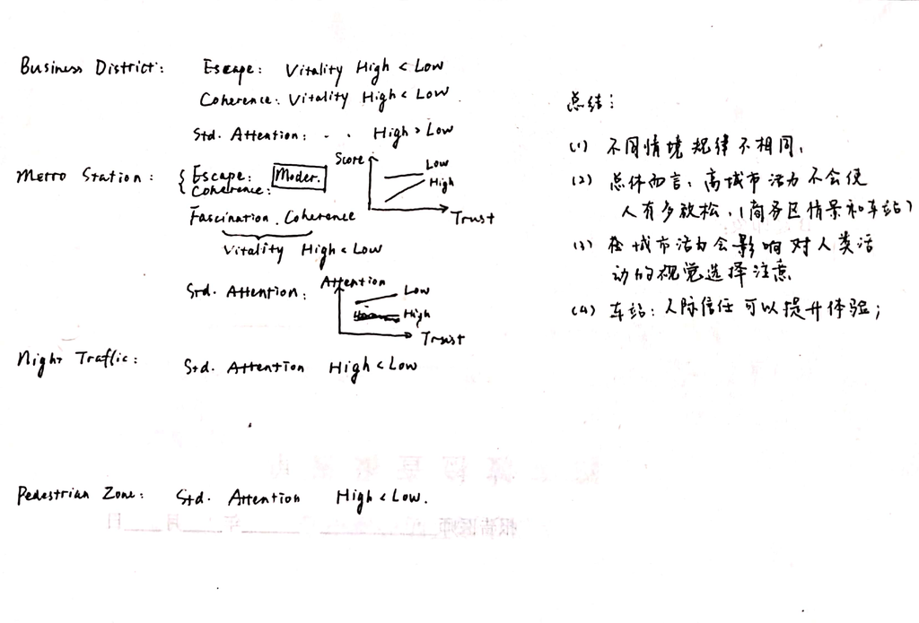

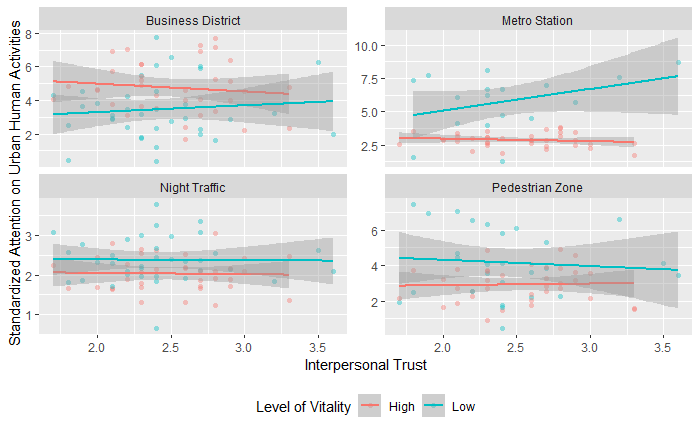